# Praktikum 5 Anreg

# Library

```r
library(readxl) # untuk membaca data
library(GGally) # untuk menghasilkan matriks hubungan antarpeubah
```

```r
library(corrplot) # untuk menghasilkan matriks korelasi
library(dplyr) # untuk manipulasi data
library(car) # untuk memeriksa multikolinearitas
```

# Data

```r
data <- read_excel("C:\\Users\\Lenovo\\Downloads\\SEM 4\\ANREG\\data anreg\\DATA Persentase Pekerja Anak (usia 10-17 tahun) Menurut Provinsi, 2023.xlsx")
head(data) # menampilkan sekian data awal
```

```
## # A tibble: 6 × 7
##   Provinsi           PPA     GK  PDRB   TPT   RLS  TPPT
##   <chr>            <dbl>  <dbl> <dbl> <dbl> <dbl> <dbl>
## 1 ACEH              1.03 627534  4.23  6.03  9.55  97.4
## 2 SUMATERA UTARA    3.97 602999  5.01  5.89  9.82  96.0
## 3 SUMATERA BARAT    2.68 667925  4.62  5.94  9.28  96.7
## 4 RIAU              2.22 658611  4.21  4.23  9.32  95.0
## 5 JAMBI             1.94 599688  4.67  4.53  8.81  96.4
## 6 SUMATERA SELATAN  2.33 520754  5.08  4.11  8.5   98.2
```

```r
str(data) # menampilkan tipe data setiap peubah
```

```
## tibble [38 × 7] (S3: tbl_df/tbl/data.frame)
##  $ Provinsi: chr [1:38] "ACEH" "SUMATERA UTARA" "SUMATERA BARAT" "RIAU" ...
##  $ PPA     : num [1:38] 1.03 3.97 2.68 2.22 1.94 2.33 1.88 2.49 3.04 1.99 ...
##  $ GK      : num [1:38] 627534 602999 667925 658611 599688 ...
##  $ PDRB    : num [1:38] 4.23 5.01 4.62 4.21 4.67 5.08 4.28 4.55 4.38 5.16 ...
##  $ TPT     : num [1:38] 6.03 5.89 5.94 4.23 4.53 4.11 3.42 4.23 4.56 6.8 ...
##  $ RLS     : num [1:38] 9.55 9.82 9.28 9.32 8.81 ...
##  $ TPPT    : num [1:38] 97.4 96 96.7 95 96.4 ...
```

```r
summary(data) # menampilkan ringkasan data
```

```
##    Provinsi              PPA              GK              PDRB
##  Length:38          Min.   :0.000   Min.   :     0   Min.   : 0.000
##  Class :character   1st Qu.:1.802   1st Qu.:481992   1st Qu.: 4.242
##  Mode  :character   Median :2.270   Median :566491   Median : 4.825
##                     Mean   :2.521   Mean   :534559   Mean   : 4.825
##                     3rd Qu.:3.853   3rd Qu.:653244   3rd Qu.: 5.140
##                     Max.   :5.610   Max.   :874204   Max.   :20.490
##       TPT             RLS              TPPT
##  Min.   :0.000   Min.   : 0.000   Min.   : 0.00
##  1st Qu.:3.080   1st Qu.: 8.033   1st Qu.:94.12
##  Median :4.270   Median : 8.785   Median :95.62
##  Mean   :4.128   Mean   : 7.988   Mean   :84.95
##  3rd Qu.:5.362   3rd Qu.: 9.335   3rd Qu.:96.53
##  Max.   :7.520   Max.   :11.450   Max.   :99.86
```

Data yang digunakan adalah data dari 38 provinsi di Indonesia pada Tahun 2023 dengan 1 peubah respon yaitu Persentase Pekerja Anak (PPA) dan 5 peubah penjelas yang semuanya merupakan peubah kuantitatif. Peubah tersebut adalah Garis Kemiskinan (GK), Produk Domestik Regional Bruto (PDRB), Tingkat Pengangguran Terbuka (TPT), Rata-rata Lama Sekolah (RLS), dan Tingkat partisipasi dalam pembelajaran yang teroganisir (TPPT). Untuk mempermudah dalam komputasi, karena peubah provinsi tidak digunakan, maka dapat dihapus. Pada praktikum kali ini akan dilakukan satu pemodelan, yakni model dengan seluruh peubah kuantitatif.

```r
data <- select(data, -Provinsi)
```

# Eksplorasi data

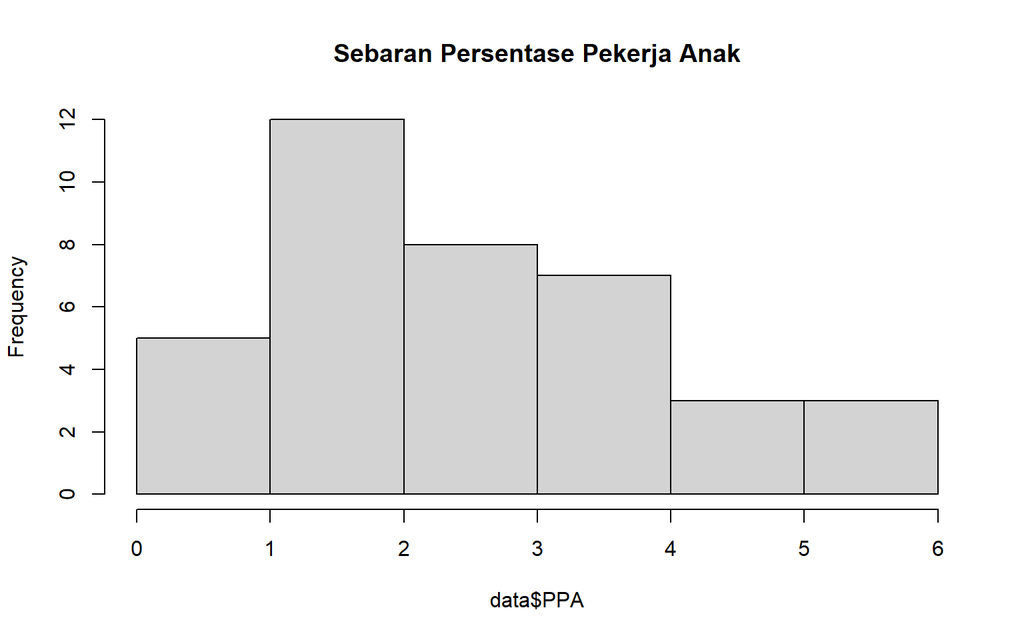

```r
hist(data$PPA, main = "Sebaran Persentase Pekerja Anak")
```

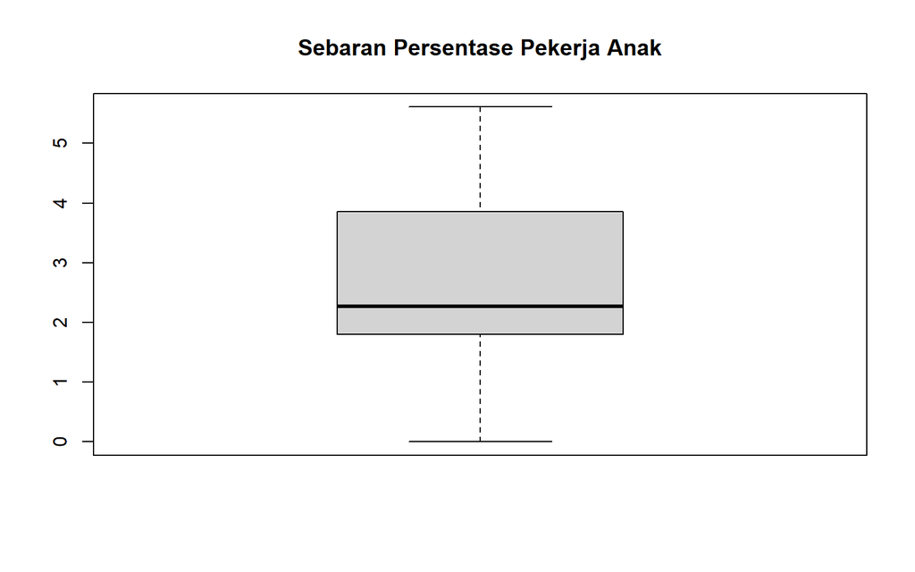

```r
boxplot(data$PPA, main = "Sebaran Persentase Pekerja Anak")
```

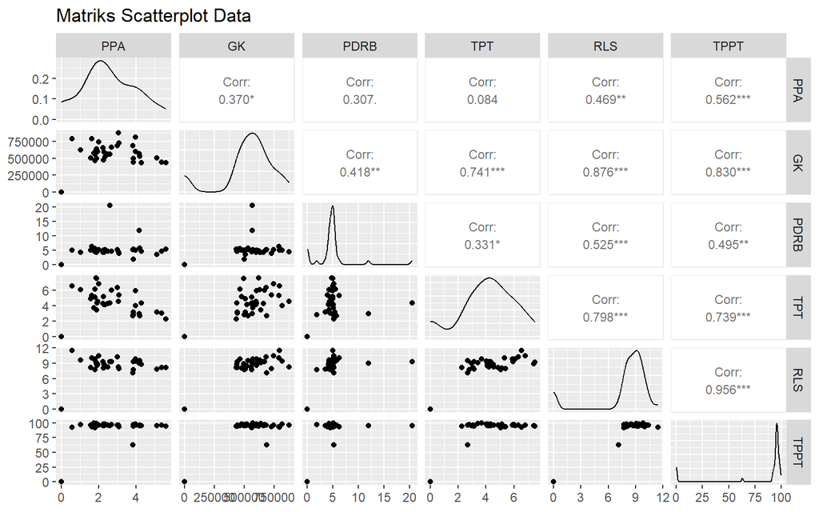

```r
ggpairs(data,
        upper = list(continuous = wrap('cor', size = 3)),
        title = "Matriks Scatterplot Data")
```

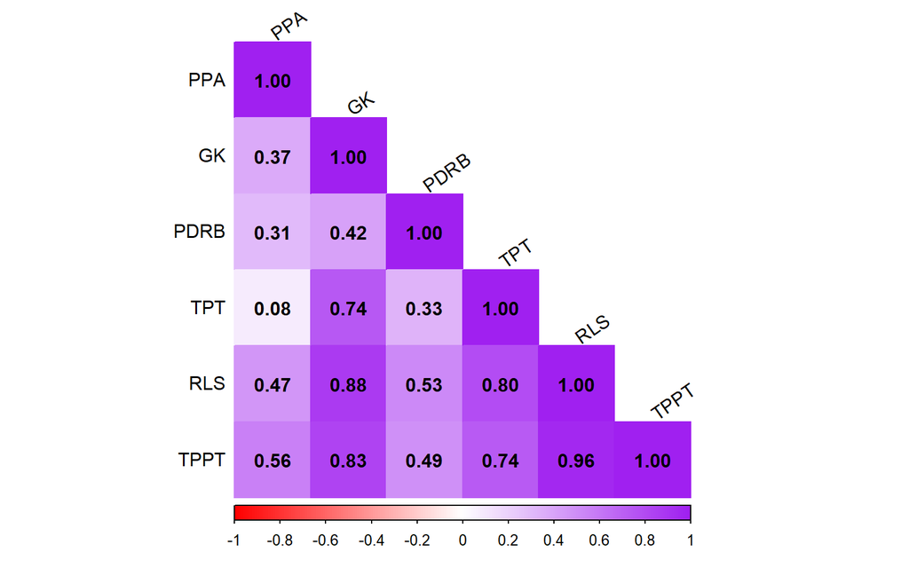

```r
cor_matrix <- cor(data, use = "complete.obs")

corrplot(cor_matrix, method = "color", type = "lower",
         col = colorRampPalette(c("red", "white", "purple"))(200),
         addCoef.col = "black", tl.col = "black", tl.srt = 35)
```

Selain itu, terdapat banyak korelasi tinggi antar peubah penjelas, yang lebih dari 0.5. Beberapa di antaranya adalah: 1. TPT dan GK memiliki korelasi 0.741. 2. RLS dengan GK dan TPT masing-masing sebesar 0.876 dan 0.798. 3. TPPT dengan GK, TPT, dan RLS masing-masing sebesar 0.830, 0.739, dan 0.956.

Korelasi yang tinggi ini mengindikasikan adanya potensi multikolinearitas, yang dapat mempengaruhi keakuratan model yang akan dibentuk.

# Pemodelan

## Tanpa Fungsi

Perhitungan nilai $\hat{\beta}$ secara matriks dapat dilakukan dengan rumus berikut.

$$\hat{\beta} = (X'X)^{-1}
X'y$$

```r
# pembentukan matriks
n <- nrow(data)
x0 <- rep(1,n)
x <- data.frame(x0, data$GK, data$PDRB, data$TPT, data$RLS, data$TPPT)
x <- as.matrix(x)
y <- data$PPA
```

```r
beta_duga <- solve(t(x)%*%x)%*%t(x)%*%y
beta_duga
```

```
##                    [,1]
## x0         1.948447e-01
## data.GK   -7.649297e-08
## data.PDRB  2.162832e-03
## data.TPT  -5.456882e-01
## data.RLS  -6.756361e-05
## data.TPPT  5.426760e-02
```

$$Var(\hat{\beta}_j) = \hat{\sigma}^2
C_{jj}$$
Dengan matriks $C$ adalah matriks $(X'X)^{-1}$

```r
c <- data.frame(solve(t(x)%*%x))
```

Unsur diagonal dari matriks $C$ dapat digunakan untuk menghitung nilai galat baku dari setiap dugaan parameter. Galat baku ini dapat digunakan untuk menghitung selang kepercayaan dari dugaan yang dihasilkan.

$$SE(\hat{\beta}_j) =
\sqrt{Var(\hat{\beta}_j)} = \sqrt{\sigma^2 C_{jj}} =
\hat{\sigma}\sqrt{c_{ii}}$$

Misal ingin dihitung selang kepercayaan dari dugaan parameter $\beta_2$, maka

```r
y_hat <- x %*% beta_duga
residuals <- y - y_hat
n <- nrow(x)
p <- ncol(x)
KTG <- sum(residuals^2) / (n - p)

c22 <- c[2,2]

(se.b2 <- sqrt(KTG*c22))
```

```
## [1] 1.685594e-06
```

```r
alfa <- 0.05

#Batas Bawah beta2
(bb.b2 <- beta_duga[3,1] - abs(qt(alfa/2, df=n-p))*se.b2)
```

```
##   data.PDRB
## 0.002159399
```

```r
#Batas Atas beta2
(ba.b2 <- beta_duga[3,1] + abs(qt(alfa/2, df=n-p))*se.b2)
```

```
##   data.PDRB
## 0.002166265
```

# Dengan Fungsi

```r
model1 <- lm(formula = PPA ~ ., data = data)
summary(model1)
```

```
##
## Call:
## lm(formula = PPA ~ ., data = data)
##
## Residuals:
##     Min      1Q  Median      3Q     Max
## -1.8169 -0.7553 -0.1948  0.6742  1.8128
##
## Coefficients:
##               Estimate Std. Error t value Pr(>|t|)
## (Intercept)  1.948e-01  5.209e-01   0.374  0.71084
## GK          -7.649e-08  1.686e-06  -0.045  0.96409
## PDRB         2.163e-03  6.268e-02   0.035  0.97269
## TPT         -5.457e-01  1.516e-01  -3.599  0.00106 **
## RLS         -6.756e-05  2.615e-01   0.000  0.99980
## TPPT         5.427e-02  1.985e-02   2.734  0.01011 *
## ---
## Signif. codes:  0 '***' 0.001 '**' 0.01 '*' 0.05 '.' 0.1 ' ' 1
##
## Residual standard error: 1.055 on 32 degrees of freedom
## Multiple R-squared:  0.5579, Adjusted R-squared:  0.4888
## F-statistic: 8.075 on 5 and 32 DF,  p-value: 5.131e-05
```

# Pemeriksaan Multikoliniearitas

```r
vif(model1)
```

```
##        GK      PDRB       TPT       RLS      TPPT
##  4.414648  1.437577  2.947382 19.224186 11.834941
```

Hasil uji ini menunjukkan peubah RLS dan TPPT memiliki nilai VIF yang sangat tinggi (>10). Pada analisis kali ini, penanganan dilakukan dengan menghapus dua peubah dengan VIF tertinggi yaitu RLS dan TPPT.

# Pemodelan Kedua

```r
model2 <- lm(PPA ~ GK + PDRB + TPT, data = data)
summary(model2)
```

```
##
## Call:
## lm(formula = PPA ~ GK + PDRB + TPT, data = data)
##
## Residuals:
##     Min      1Q  Median      3Q     Max
## -2.2450 -1.0316 -0.1187  0.5223  2.9142
##
## Coefficients:
##               Estimate Std. Error t value Pr(>|t|)
## (Intercept)  1.221e+00  5.984e-01   2.040   0.0492 *
## GK           4.156e-06  1.570e-06   2.648   0.0122 *
## PDRB         8.686e-02  7.280e-02   1.193   0.2410
## TPT         -3.248e-01  1.663e-01  -1.953   0.0591 .
## ---
## Signif. codes:  0 '***' 0.001 '**' 0.01 '*' 0.05 '.' 0.1 ' ' 1
##
## Residual standard error: 1.333 on 34 degrees of freedom
## Multiple R-squared:  0.2494, Adjusted R-squared:  0.1831
## F-statistic: 3.765 on 3 and 34 DF,  p-value: 0.01951
```

Persamaan yang terbentuk adalah
$$\hat{PPM}=1.2210+0.0000042GK+0.0869PDRB−0.3248TPT$$

```r
vif(model2)
```

```
##       GK     PDRB      TPT
## 2.395845 1.213453 2.219953
```

Model hasil reduksi peubah menunjukkan nilai VIF < 10 sehingga tidak terjadi multikolinearitas. Secara simultan, model sudah signifikan dengan F-statistik sebesar 3,765 dan p-value 0,01951. Namun secara parsial, hanya peubah GK yang signifikan pada
$${\alpha}$$
= 0,05, sedangkan PDRB dan TPT belum signifikan. Kondisi ini mengindikasikan adanya permasalahan lain yang belum tertangani, sehingga perlu dilakukan uji asumsi klasik serta pemeriksaan pencilan, leverage, dan amatan berpengaruh.

# Uji Hipotesis Kesamaan Parameter Regresi

Misal ingin dilakukan pemodelan dengan peubah respon Persentase pekerja Anak dengan 3 peubah penjelas, yaitu GK, TPT, dan RLS.

```r
model4 <- lm(PPA ~ GK + TPT + RLS, data = data)
summary(model4)
```

```
##
## Call:
## lm(formula = PPA ~ GK + TPT + RLS, data = data)
##
## Residuals:
##      Min       1Q   Median       3Q      Max
## -2.43743 -0.58150 -0.08822  0.69431  2.12314
##
## Coefficients:
##               Estimate Std. Error t value Pr(>|t|)
## (Intercept)  5.140e-01  5.471e-01   0.940 0.354092
## GK          -2.147e-07  1.810e-06  -0.119 0.906264
## TPT         -6.005e-01  1.597e-01  -3.760 0.000640 ***
## RLS          5.760e-01  1.501e-01   3.838 0.000513 ***
## ---
## Signif. codes:  0 '***' 0.001 '**' 0.01 '*' 0.05 '.' 0.1 ' ' 1
##
## Residual standard error: 1.137 on 34 degrees of freedom
## Multiple R-squared:  0.4544, Adjusted R-squared:  0.4062
## F-statistic: 9.438 on 3 and 34 DF,  p-value: 0.0001114
```

```r
vif(model4)
```

```
##       GK      TPT      RLS
## 4.381944 2.815730 5.449691
```

Hasil pemodelan tersebut dapat dilakukan serangkaian uji untuk memeriksa apakah $β_2=β_3$ dapat diasumsikan sama ketika parameter lainnya tidak signifikan atau diasumsikan sama dengan nol.

Hipotesis yang diuji adalah

$$H_0: β2=β3$$
$$H_1: β2≠β3$$

Karena peubah GK tidak signifikan maka dapat diasumsikan nol sehingga model dapat disederhanakan menjadi:

$$PPM=β_0+β_2TPT+β_3RLS+ε$$
Jika $H_0$ benar $(β_2β_3=β_1')$, model bisa ditulis ulang sebagai

$$PPM=β_0+β_1'
(TPT+RLS)+ε$$

```r
# Buat peubah baru
data$X_new <- data$TPT + data$RLS

# Model penuh (Full Model)
model_full <- lm(PPA ~ TPT + RLS, data = data)

# Model terbatas (Restricted Model)
model_restricted <- lm(PPA ~ X_new, data = data)

# Bandingkan dengan Uji F
anova(model_restricted, model_full)
```

```
## Analysis of Variance Table
##
## Model 1: PPA ~ X_new
## Model 2: PPA ~ TPT + RLS
##   Res.Df    RSS Df Sum of Sq      F    Pr(>F)
## 1     36 71.721
## 2     35 43.945  1    27.777 22.123 3.916e-05 ***
## ---
## Signif. codes:  0 '***' 0.001 '**' 0.01 '*' 0.05 '.' 0.1 ' ' 1
```

Hasil perbandingan menunjukkan bahwa nilai p kurang dari alpha sehingga dapat disimpulkan bahwa tolak H0, artinya peubah TPT dan RLS berbeda secara signifikan sehingga tidak dapat digabung. Selanjutnya dapat dipilih apakah akan menggunakan peubah dengan 3 peubah atau hanya 2 peubah berdasarkan indikator AIC dan BIC.

```r
model_all <- lm(PPA ~ GK + TPT + RLS, data = data)
summary(model_all)
```

```
##
## Call:
## lm(formula = PPA ~ GK + TPT + RLS, data = data)
##
## Residuals:
##      Min       1Q   Median       3Q      Max
## -2.43743 -0.58150 -0.08822  0.69431  2.12314
##
## Coefficients:
##               Estimate Std. Error t value Pr(>|t|)
## (Intercept)  5.140e-01  5.471e-01   0.940 0.354092
## GK          -2.147e-07  1.810e-06  -0.119 0.906264
## TPT         -6.005e-01  1.597e-01  -3.760 0.000640 ***
## RLS          5.760e-01  1.501e-01   3.838 0.000513 ***
## ---
## Signif. codes:  0 '***' 0.001 '**' 0.01 '*' 0.05 '.' 0.1 ' ' 1
##
## Residual standard error: 1.137 on 34 degrees of freedom
## Multiple R-squared:  0.4544, Adjusted R-squared:  0.4062
## F-statistic: 9.438 on 3 and 34 DF,  p-value: 0.0001114
```

```r
model_signif <- lm(PPA ~ TPT + RLS, data = data)
summary(model_signif)
```

```
##
## Call:
## lm(formula = PPA ~ TPT + RLS, data = data)
##
## Residuals:
##     Min      1Q  Median      3Q     Max
## -2.4430 -0.5668 -0.0811  0.6661  2.1415
##
## Coefficients:
##             Estimate Std. Error t value Pr(>|t|)
## (Intercept)   0.5104     0.5385   0.948 0.349716
## TPT          -0.6032     0.1558  -3.872 0.000452 ***
## RLS           0.5634     0.1052   5.355 5.48e-06 ***
## ---
## Signif. codes:  0 '***' 0.001 '**' 0.01 '*' 0.05 '.' 0.1 ' ' 1
##
## Residual standard error: 1.121 on 35 degrees of freedom
## Multiple R-squared:  0.4541, Adjusted R-squared:  0.423
## F-statistic: 14.56 on 2 and 35 DF,  p-value: 2.505e-05
```

```r
perbandingan <- data.frame(
  Model = c("Peubah Penuh", "Peubah Signifikan"),
  AIC = as.numeric(c(AIC(model_all), AIC(model_signif))),
  BIC = as.numeric(c(BIC(model_all), BIC(model_signif)))
)
perbandingan
```

```
##               Model      AIC      BIC
## 1      Peubah Penuh 123.3467 131.5347
## 2 Peubah Signifikan 121.3625 127.9128
```

Berdasarkan indikator AIC dan BIC maka model dengan hanya dua peubah dipilih sebagai model yang terbaik. Persamaan yang terbentuk adalah sebagai berikut

$$\hat{PPA}=0.5104-0.6032TPT+0.5634RLS$$
Interpretasi:
1. Dugaan rataan persentase pekerja anak jika TPT dan RLS bernilai 0 adalah 0.5104%
2. Dugaan rataan persentase pekerja anak akan menurun 0.6032% apabila rata-rata tingkat pengangguran terbuka meningkat satu persen dengan asumsi rata-rata lama sekolah konstan
3. Dugaan rataan persentase pekerja anak akan meningkat 0.5634% apabila rata-rata lama sekolah meningkat satu persen dengan asumsi rata-rata tingkat pengangguran terbuka konstan